# 7. Analysis of Variance

Author

Lieven Clement

Published

Invalid Date

# 1 Prostacycline dataset

- Effect van arachidonzuur op het prostacycline niveau in het bloedplasma.
- 3 verschillende concentraties van arachidonzuur:
  - laag (L, 10 eenheden)
  - gemiddeld (M, 25 eenheden)
  - hoge dosis (H, 50 eenheden)
- Prostacycline concentratie in bloed plasma via gecalibreerde elisa fluorescentie meting
- 12 ratten worden at random toegekend aan elke behandelingsgroep.
- Factoriële proef, *volledige gerandomiseerde proefopzet*, *“completely randomized design” CRD*.

```r
prostacyclin <- read_tsv("https://raw.githubusercontent.com/statOmics/sbc/master/data/prostacyclin.txt")

prostacyclin <- prostacyclin |>
  mutate(dose = as.factor(prostacyclin$dose))

head(prostacyclin)
```

```
# A tibble: 6 × 2
  prostac dose
    <dbl> <fct>
1    19.2 10
2    10.8 10
3    33.6 10
4    11.9 10
5    15.9 10
6    33.3 10
```

## 1.1 Data exploration

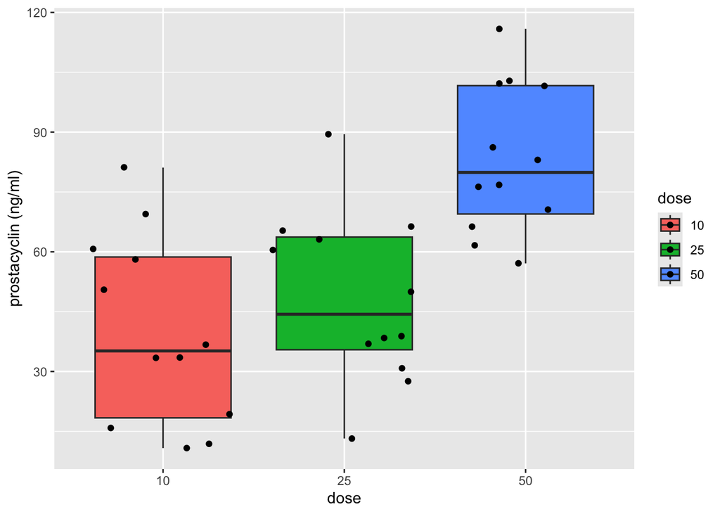

```r
prostacyclin |>
  ggplot(aes(x = dose, y = prostac, fill = dose)) +
  geom_boxplot() +
  geom_point(position = "jitter") +
  ylab("prostacyclin (ng/ml)")
```

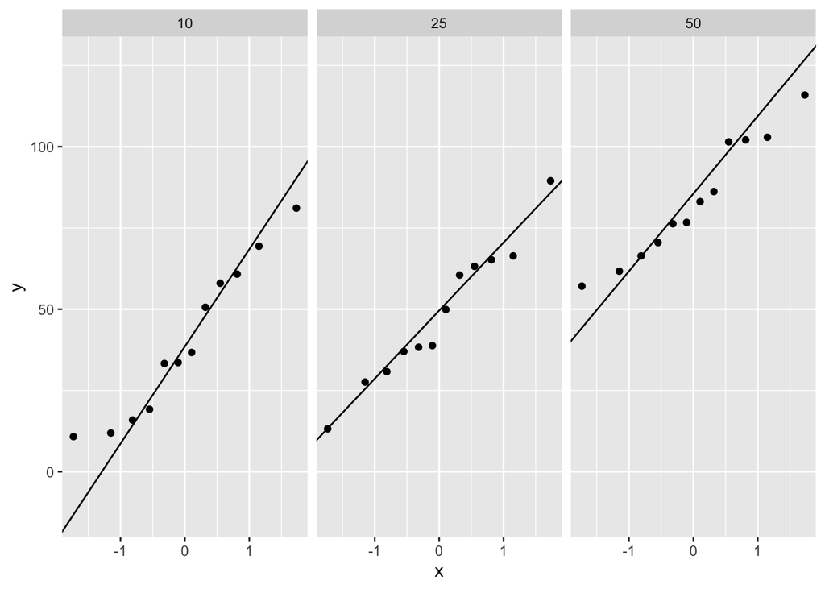

```r
prostacyclin |>
  ggplot(aes(sample = prostac)) +
  geom_qq() +
  geom_qq_line() +
  facet_grid(~ dose)
```

Data in de drie groepen lijkt normaal verdeeld en de variantie is ongeveer gelijk:
$$Y_i \vert \text{groep j} \sim N(\mu_j,\sigma^2),$$
met $j= \text{1, 2, 3}$

## 1.2 Onderzoeksvraag

Vraagstelling kan vertaald worden in volgende hypotheses

- $H_0$: De arachidonzuurconcentratie heeft geen effect op het gemiddelde prostacycline niveau bij ratten
  $$H_0:\mu_1=\mu_2 = \mu_3$$
- $H_1$: De arachidonzuurconcentratie heeft een effect op het gemiddelde prostacycline niveau bij ratten. Wat betekent dat minstens twee gemiddelden verschillend zijn:
  $$H_1: \exists\ j,k \in \{1,\ldots,g\} : \mu_j\neq\mu_k$$

**naïeve benadering**: nulhypothese op splitsen in **partiële hypotheses**
$$H_{0jk}: \mu_j=\mu_k \text{ versus } H_{1jk}: \mu_j \neq \mu_k$$

Elk van deze partiële hypotheses testen met two-sample $t$-testen

$\rightarrow$ Probleem van meervoudig toetsen + verlies van power.

$\rightarrow$ $H_0:\mu_1=\mu_2=\mu_3$ testen met **1 enkele test**.

# 2 Analyse van variantie

- Correcte oplossing voor het testprobleem: **variantie-analyse**, afgekort door ANOVA (ANalysis Of VAriance)
- We leiden de methode af voor de meest eenvoudige uitbreiding met 3 groepen (prostacycline voorbeeld)
- Data modelleren a.d.h.v een lineair model door gebruik te maken van dummy variabelen.
- 1 dummy variable minder nodig hebben dan het aantal groepen. Hier dus 2 dummy variabelen.
- De veralgemening naar g groepen $g>3$ is triviaal (extra dummy variabelen)

## 2.1 Model

$$\begin{eqnarray}
Y_i &=& g(x_{i1},x_{i2}) + \epsilon_i\\
Y_i &=& \beta_0+\beta_1 x_{i1} +\beta_2 x_{i2} +\epsilon_i
\end{eqnarray}$$

- $Y_i$ de uitkomst voor observatie $i$ ($i=1,\ldots, n$)
- $\epsilon_i\text{i.i.d.} N(0,\sigma^2)$
- en dummyvariabelen
  $$x_{i1} = \left\{ \begin{array}{ll}
  1 & \text{ als observatie $i$ tot de middelste dosisgroep behoort (M)} \\
  0 & \text{ als observatie $i$ behoort tot een andere dosisgroep} \end{array}\right.$$
  $$x_{i2} = \left\{ \begin{array}{ll}
  1 & \text{ als observatie $i$ behoort tot de groep met hoge doses (H)} \\
  0 & \text{als observatie $i$ behoort tot een andere dosisgroep} \end{array}\right. .$$
- Lage dosis groep (L) with $x_{i1}=x_{i2}=0$ is *referentie groep*

Regressiemodel kan worden herschreven als een model voor elke groep:
$$\begin{eqnarray*}
Y_{i\vert \text{dose=L}} &=& \beta_0+\epsilon_i \\
Y_{i\vert \text{dose=M}} &=& \beta_0+\beta_1+ \epsilon_i \\
Y_{i\vert \text{dose=H}} &=& \beta_0+\beta_2 + \epsilon_i
\end{eqnarray*}$$
met $\epsilon_i \sim N(0,\sigma^2)$

Interpretatie van model parameters:
$$\begin{eqnarray*}
\beta_0 &=& \text{E}\left[Y_i \mid \text{Behandeling met lage dosis groep L}\right] \\
\beta_1 &=& (\beta_0+\beta_1)-\beta_0 = \text{E}\left[Y_i \mid \text{behandeling M}\right] - \text{E}\left[Y_i \mid \text{behandeling L}\right] \\
\beta_2 &=& (\beta_0+\beta_2)-\beta_0 = \text{E}\left[Y_i \mid \text{behandeling H}\right]-\text{E}\left[Y_i \mid \text{behandeling L}\right].
\end{eqnarray*}$$

1. $\beta_0$ is gemiddelde uitkomst in groep L
2. $\beta_1$ is effect (verschil in gemiddelde concentratie) van groep M t.o.v. groep L
3. $\beta_2$ is effect van groep H t.o.v. groep L

We herformuleren het model door $\mu$-notaties te gebruiken:
$$\begin{eqnarray*}
Y_{i\vert \text{dose=L}} &=& \beta_0+\epsilon_i = \mu_1+\epsilon_i \\
Y_{i\vert \text{dose=M}} &=& \beta_0+\beta_1+ \epsilon_i = \mu_2+\epsilon_i \\
Y_{i\vert \text{dose=H}} &=& \beta_0+\beta_2 + \epsilon_i = \mu_3+\epsilon_i .
\end{eqnarray*}$$
met $\epsilon_i \sim N(0,\sigma^2)$ en
$$\mu_j = \text{E}\left[Y_i \mid \text{treatment group } j\right].$$

De oorspronkelijk nulhypothese $H_0:\mu_1=\mu_2=\mu_3$ kan equivalent geformuleerd worden als

$$H_0: \beta_1=\beta_2=0$$

Model laat toe om methoden van lineaire regressie te gebruiken voor meervoudig vergelijken van gemiddelden.

- Parameterschatting van parameters, varianties en standard errors uit theorie van lineaire regressie
- Inferentie: Betrouwbaarheidsintervallen, hypothesetests
- Test $H_0: \beta_1=\beta_2=0$ met $F$-test.

## 2.2 Prostacyclin voorbeeld

```r
model1 <- lm(prostac ~ dose, data = prostacyclin)
summary(model1)
```

```
Call:
lm(formula = prostac ~ dose, data = prostacyclin)

Residuals:
    Min      1Q  Median      3Q     Max
-35.167 -17.117  -4.958  17.927  41.133

Coefficients:
            Estimate Std. Error t value Pr(>|t|)
(Intercept)   40.108      6.150   6.521 2.10e-07 ***
dose25         8.258      8.698   0.949    0.349
dose50        43.258      8.698   4.974 1.99e-05 ***
---
Signif. codes:  0 '***' 0.001 '**' 0.01 '*' 0.05 '.' 0.1 ' ' 1

Residual standard error: 21.3 on 33 degrees of freedom
Multiple R-squared:  0.458, Adjusted R-squared:  0.4252
F-statistic: 13.94 on 2 and 33 DF,  p-value: 4.081e-05
```

# 3 Kwadratensommen en Anova

Zoals bij enkelvoudige regressie kwadratensom van regressie gebruiken bij het opstellen van de F-test.
$$\begin{eqnarray*}
\text{SSR}&=&\sum\limits_{i=1}^n (\hat Y_i -\bar Y)^2\\
&=& \sum\limits_{i=1}^n (\hat{g} (x_{i1},x_{i2}) - \bar Y)^2\\
&=& \sum\limits_{i=1}^n (\hat\beta_0+\hat\beta_1x_{i1}+\hat\beta_2x_{i2}) - \bar Y)^2\\
&=& \sum\limits_{i=1}^{n_1} (\hat\beta_0 - \bar Y)^2 +\sum\limits_{i=1}^{n_2} (\hat\beta_0 + \hat\beta_1 - \bar Y)^2+\sum\limits_{i=1}^{n_3} (\hat\beta_0 + \hat\beta_2 - \bar Y)^2\\
&=& \sum\limits_{i=1}^{n_1} (\bar Y_1- \bar Y)^2 +\sum\limits_{i=1}^{n_2} (\bar Y_2- \bar Y)^2+\sum\limits_{i=1}^{n_3} (\bar Y_3 - \bar Y)^2\\
\end{eqnarray*}$$
met $n_1$, $n_2$ en $n_3$ het aantal waarnemingen in elke groep (hier $n-1=n_2=n_3=12$).

$$\begin{eqnarray*}
\text{SSR}&=&\sum\limits_{i=1}^n (\hat Y_i -\bar Y)^2
\end{eqnarray*}$$

- Kwadratensom opnieuw equivalent aan vergelijken van model (1) en een gereduceerd model met enkel een intercept.
- Voor gereduceerd model zal intercept worden geschat door steekproefgemiddelde.
- Deze kwadratensom heeft dus g-1=2 vrijheidsgraden:
  - g=3 model parameters - 1 parameter voor steekproefgemiddelde of
  - g=3 par. van complexe model - 1 par. van gereduceerde model.

## 3.1 Ontbinding van de Totale Kwadratensom

- De conventie in een Anova setting is om de kwadratensom te noteren als SST, de **kwadratensom van de behandeling (treatment)** of als SSBetween.
- De kwadratensom van de regressie geeft voor model (1) inderdaad de variabiliteit weer tussen de groepen.
- De overeenkomstige gemiddelde kwadratensom wordt dan $\text{MST}=\text{SST}/2$.

De decompositie van SSTot wordt dan geschreven als
$$\text{SSTot} = \text{SST} + \text{SSE}$$

## 3.2 SSTot

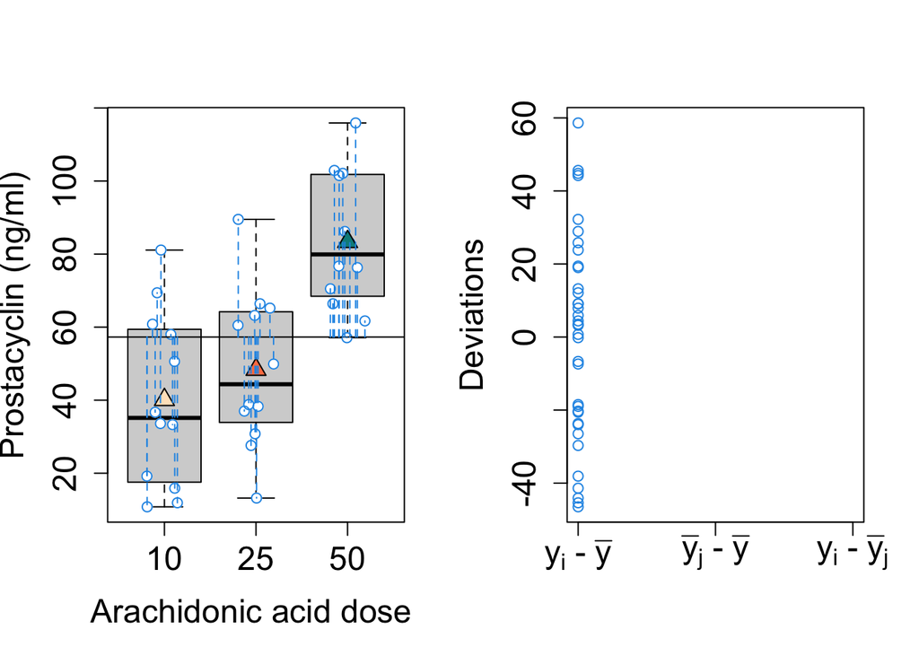

## 3.3 SST

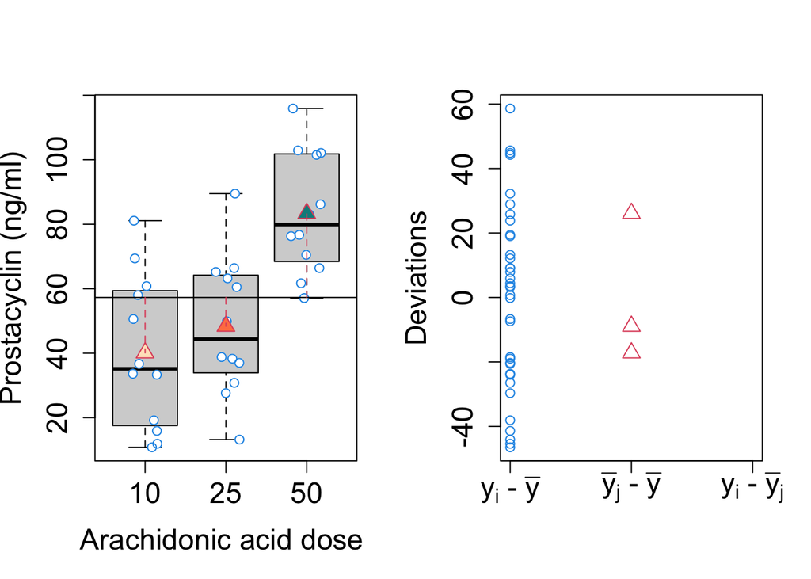

## 3.4 SSE

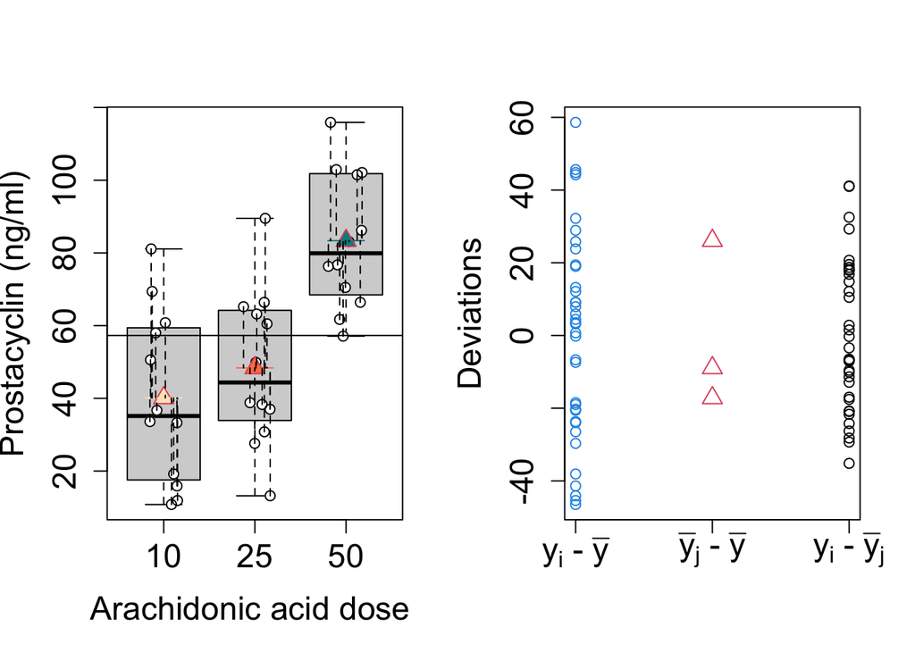

## 3.5 Anova test

Test $H_0: \beta_1=\beta_2=0$ met $F$-test.
$$F = \frac{\text{MST}}{\text{MSE}}$$

met

- $\text{MST}=\text{SST}/(g-1)$
- $\text{MSE}=\text{SSE}/(n-p)$
- Teststatistiek vergelijkt de variabiliteit verklaard door model (MST) met de residuele variabiliteit (MSE)

of

- Variabiliteit tussen groepen (MST) tot variabiliteit binnen groepen (MSE)
- onder $H_0$: $F \sim F_{g-1,n-g}$, met g=3.

## 3.6 Anova Tabel

|  | Df | Sum Sq | Mean Sq | F value | Pr(>F) |
| --- | --- | --- | --- | --- | --- |
| Treatment | d.f. SST | SST | MST | F-statistiek | p-waarde |
| Error | d.f. SSE | SSE | MSE |  |  |

```r
anova(model1)
```

```
Analysis of Variance Table

Response: prostac
          Df Sum Sq Mean Sq F value    Pr(>F)
dose       2  12658  6329.0  13.944 4.081e-05 ***
Residuals 33  14979   453.9
---
Signif. codes:  0 '***' 0.001 '**' 0.01 '*' 0.05 '.' 0.1 ' ' 1
```

### 3.6.1 F-verdeling met kritieke waarde ($\alpha$=5%) en geobserveerde F-statistiek voor prostacycline voorbeeld

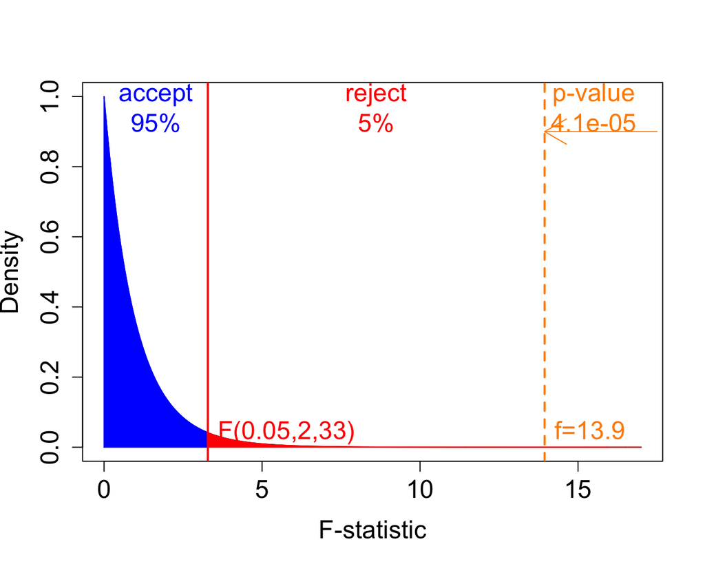

### 3.6.2 F-verdeling met verschillend aantal vrijheidsgraden in de noemer en teller

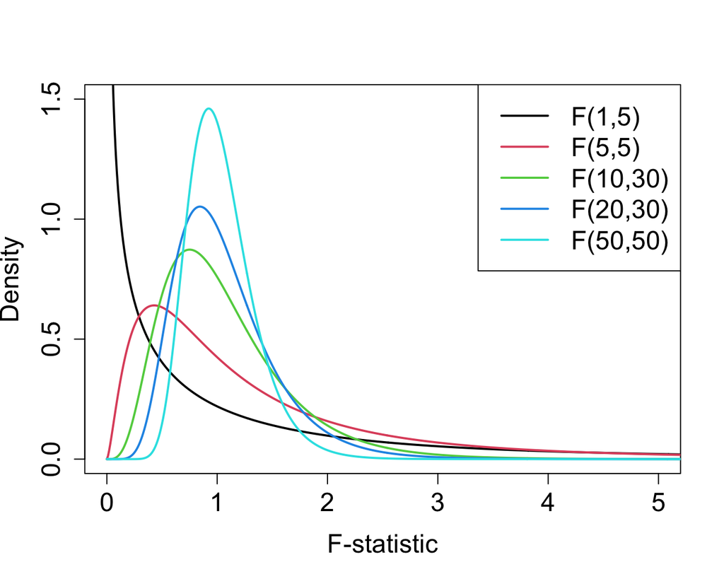

### 3.6.3 Prostacyclin voorbeeld: welke groepen zijn verschillend?

```r
summary(model1)
```

```
Call:
lm(formula = prostac ~ dose, data = prostacyclin)

Residuals:
    Min      1Q  Median      3Q     Max
-35.167 -17.117  -4.958  17.927  41.133

Coefficients:
            Estimate Std. Error t value Pr(>|t|)
(Intercept)   40.108      6.150   6.521 2.10e-07 ***
dose25         8.258      8.698   0.949    0.349
dose50        43.258      8.698   4.974 1.99e-05 ***
---
Signif. codes:  0 '***' 0.001 '**' 0.01 '*' 0.05 '.' 0.1 ' ' 1

Residual standard error: 21.3 on 33 degrees of freedom
Multiple R-squared:  0.458, Adjusted R-squared:  0.4252
F-statistic: 13.94 on 2 and 33 DF,  p-value: 4.081e-05
```

Met output van model kunnen we ook testen of de gemiddelde prostacycline concentratie verschillend is tussen de matige en lage dosis groep ($\beta_1$: dose25) en tussen de hoge en lage dosis groep ($\beta_2$: dose50).

De p-waarden houden geen rekening met het feit dat we meervoudig toetsen.

# 4 Post hoc analysis: Meerdere vergelijkingen van gemiddelden

## 4.1 Naïeve methode

In eerste deel van dit hoofdstuk hebben we $F$-test besproken voor het testen van

$$H_0: \mu_1=\cdots = \mu_g \text{ versus } H_1: H_1: \exists\ j,k \in \{1,\ldots,g\} : \mu_j\neq\mu_k$$

- Als we $H_0$ verwerpen besluiten we dat er minstens twee gemiddelden verschillen van elkaar.
- De methode niet in staat om te identificeren welke gemiddelden van elkaar verschillen.

Een eerste, maar naïeve benadering: $H_0$ opsplitsen in partiële hypotheses
$$H_{0jk}: \mu_j=\mu_k \text{ versus } H_{1jk}: \mu_j \neq \mu_k$$

- partiële hypotheses testen met two-sample $t$-testen
- Voor vergelijken van groep $j$ met groep $k$ wordt klassieke two-sample $t$-test onder gelijkheid van variantie gegeven door:
  $$T_{jk} = \frac{\bar{Y}_j-\bar{Y}_k}{S_p\sqrt{\frac{1}{n_j}+\frac{1}{n_k}}} \sim t_{n-2}$$

Met

- $S_p^2$ de gepoolde variantieschatter is,
  $$S_p^2 = \frac{(n_j-1)S_j^2 + (n_k-1)S_k^2}{n_j+n_k-2}$$
- met $S_j^2$ en $S_k^2$ de steekproefvarianties van respectievelijk de uitkomsten uit groep $j$ en $k$.

In ANOVA context veronderstellen we dat variantie in **alle** $g$ groepen dezelfde is: de residuele variantie $\sigma^2$.

- Gebruik van $S_p^2$ is niet efficiënt omdat die niet van alle data gebruik maakt
- Aan efficiëntie winnen door door MSE te gebruiken
  $$\text{MSE}= \sum_{j=1}^g \frac{(n_j-1)S_j^2}{n-g}$$
- De $t$-testen worden dus best gebaseerd op
  $$T_{jk} = \frac{\bar{Y}_j-\bar{Y}_k}{\text{MSE}\sqrt{\frac{1}{n_j}+\frac{1}{n_k}}} \sim t_{n-g}.$$

```r
with(
  prostacyclin,
  pairwise.t.test(prostac, dose, "none")
  )
```

```
    Pairwise comparisons using t tests with pooled SD

data:  prostac and dose

   10      25
25 0.34927 -
50 2e-05   0.00031

P value adjustment method: none
```

Het werken met $m$-testen op het $\alpha$ significantieniveau is echter een foute aanpak die de kans op een type I fout niet onder controle kan houden.

## 4.2 We tonen aan dat naïve methode niet werkt via simulatie

1. We simuleren uit een ANOVA model met $g=3$ groepen.
2. De gemiddelden in het ANOVA model zijn gelijk aan elkaar, zodat de nulhypothese
   $$H_0: \mu_1=\mu_2=\mu_3$$
   opgaat.
3. Voor iedere gesimuleerde dataset zijn er $m=3$ paarsgewijze two-sample $t$-testen
4. Zodra minstens één van de $p$-waarden kleiner is dan het significantieniveau $\alpha=5\%$, wordt de nulhypothese $H_0: \mu_1=\mu_2=\mu_3$ verworpen omdat er minstens twee gemiddelden verschillend zijn volgens de $t$-testen.
5. We rapporteren de relatieve frequentie van het verwerpen van de globale nulhypothese, meer bepaald de kans op een type I fout van de test voor $H_0: \mu_1=\mu_2=\mu_3$.

```r
g <- 3 # aantal behandelingen (g=3)
ni <- 12 # aantal herhalingen in iedere groep
n <- g*ni # totaal aantal observaties
alpha <- 0.05 # significantieniveau van een individuele test
N <- 10000 #aantal simulaties
set.seed(302) #seed zodat resultaten exact geproduceerd kunnen worden
trt <- factor(rep(1:g, ni)) #factor
cnt <- 0 #teller voor aantal foutieve verwerpingen

for(i in 1:N) {
if (i %% 1000 == 0) cat(i, "/", N, "\n")
y <- rnorm(n)
tests <- pairwise.t.test(y, trt, "none")
verwerp <- min(tests$p.value, na.rm = T) < alpha
if(verwerp) cnt <- cnt+1
}
```

```
1000 / 10000
2000 / 10000
3000 / 10000
4000 / 10000
5000 / 10000
6000 / 10000
7000 / 10000
8000 / 10000
9000 / 10000
10000 / 10000
```

```r
cnt/N
```

```
[1] 0.1209
```

- Kans op een type I fout gelijk is aan 12.1%
- Is meer dan dubbel zo groot is dan vooropgestelde $\alpha=5$%.
- Als we simulatiestudie herhalen met g = 5 groepen (i.e. 10 paarsgewijze t-testen) dan vinden we 28.0% in plaats van de gewenste 5%.
- Deze simulaties illustreren het probleem van **multipliciteit** (Engels: *multiplicity*)
  - klassieke $p$-waarden mogen enkel met het significantieniveau $\alpha$ vergeleken worden, indien het besluit op exact één $p$-waarde gebaseerd is.
  - Finale besluit (al dan niet verwerpen van $H_0: \mu_1=\cdots =\mu_g$) gebaseerd op $m=g\times(g-1)/2$ $p$-waarden.
- We bespreken eerst een uitbreiding van het begrip van type I fout en vervolgens introduceren we enkele oplossingen.

## 4.3 Family-wise error rate

- Wanneer $m>1$ toetsen worden aangewend om 1 beslissing te vormen, is het noodzakelijk te corrigeren voor het risico op vals positieve resultaten (type I fout).
- Meeste procedures voor meervoudig toetsen gaan ervan uit dat *alle $m$ nulhypotheses waar* zijn.
- Er wordt dan geprobeerd om het *risico op minstens 1 vals positief resultaat* te controleren op **experimentgewijs significantieniveau $\alpha_E$**, typisch $\alpha_E=0.05$.
- In de Engelstalige literatuur wordt het experimentgewijs significantieniveau *family-wise error rate (FWER)* genoemd.

## 4.4 Bonferroni correction

Bij het uitvoeren van $m$ onafhankelijke toetsen met elk significantieniveau $\alpha$, is
$$\begin{eqnarray*}
\alpha_E&=&\text{P}[\text{minstens 1 Type I fout}]\\
&=&1-(1-\alpha)^m \leq m\alpha
\end{eqnarray*}$$

Als alternatieve methode kunnen we ook

1. *aangepaste p-waarden* rapporteren zodat we deze met het experimentgewijze $\alpha_E$ niveau kunnen vergelijken:
   $$\tilde{p}=min(m\times p,1)$$
2. $(1-\alpha_E/m)100\%$ betrouwbaarheidsintervallen rapporteren.

### 4.4.1 Prostacyclin voorbeeld

```r
with(
  prostacyclin,
  pairwise.t.test(
    prostac,
    dose,
    p.adjust.method="bonferroni")
  )
```

```
    Pairwise comparisons using t tests with pooled SD

data:  prostac and dose

   10      25
25 1.00000 -
50 6e-05   0.00094

P value adjustment method: bonferroni
```

- Conclusies blijven gelijk behalve dat FWER nu gecontroleerd is $\alpha_E=5\%$ en $\tilde{p}$-waarden zijn factor 3 groter

Zelfde analyse kan via `multcomp` R package ontwikkeld voor multipliciteit in lineaire modellen.

```r
library(multcomp)
```

```r
library(multcomp)
model1.mcp <- glht(model1, linfct = mcp(dose = "Tukey"))
summary(model1.mcp, test = adjusted("bonferroni"))
```

```
     Simultaneous Tests for General Linear Hypotheses

Multiple Comparisons of Means: Tukey Contrasts


Fit: lm(formula = prostac ~ dose, data = prostacyclin)

Linear Hypotheses:
             Estimate Std. Error t value Pr(>|t|)
25 - 10 == 0    8.258      8.698   0.949 1.000000
50 - 10 == 0   43.258      8.698   4.974 5.98e-05 ***
50 - 25 == 0   35.000      8.698   4.024 0.000943 ***
---
Signif. codes:  0 '***' 0.001 '**' 0.01 '*' 0.05 '.' 0.1 ' ' 1
(Adjusted p values reported -- bonferroni method)
```

Om Bonferroni aangepaste betrouwbaarheidsintervallen te verkrijgen moeten we eerst zelf functie definiëren in R om bonferroni kritische waarde te bepalen.

- Bonferonni-betrouwbaarheidsintervallen worden niet geïmplementeerd omdat er betere methoden bestaan voor meervoudige tests.
- De onderstaande functie is hier alleen voor de volledigheid toegevoegd, maar we zullen over het algemeen de standaardmethode gebruiken voor meervoudige tests in multcomp.

```r
calpha_bon_t <- function(object, level)
{
  abs(
    qt(
      (1-level)/2/nrow(object$linfct),
      object$df)
    )
}
```

```r
confint(model1.mcp, calpha = calpha_bon_t)
```

```
     Simultaneous Confidence Intervals

Multiple Comparisons of Means: Tukey Contrasts


Fit: lm(formula = prostac ~ dose, data = prostacyclin)

Quantile = 2.5222
95% confidence level


Linear Hypotheses:
             Estimate lwr      upr
25 - 10 == 0   8.2583 -13.6790  30.1957
50 - 10 == 0  43.2583  21.3210  65.1957
50 - 25 == 0  35.0000  13.0626  56.9374
```

### 4.4.2 Simulatie om Bonferroni methode te evalueren

```r
g <- 3 # aantal behandelingen (g=3)
ni <- 12 # aantal herhalingen in iedere groep
n <- g*ni # totaal aantal observaties
alpha <- 0.05 # significantieniveau van een individuele test
N <- 10000 #aantal simulaties
set.seed(302) #seed zodat resultaten exact geproduceerd kunnen worden
trt <- factor(rep(1:g, ni)) #factor
cnt <- 0 #teller voor aantal foutieve verwerpingen

for(i in 1:N) {
if (i %% 1000 == 0) cat(i, "/", N, "\n")
y <- rnorm(n)
tests <- pairwise.t.test(y, trt, "bonferroni")
verwerp <- min(tests$p.value, na.rm = T) < alpha
if(verwerp) cnt <- cnt+1
}
```

```
1000 / 10000
2000 / 10000
3000 / 10000
4000 / 10000
5000 / 10000
6000 / 10000
7000 / 10000
8000 / 10000
9000 / 10000
10000 / 10000
```

```r
cnt/N
```

```
[1] 0.0457
```

- We vinden een FWER van 4.6% (een beetje conservatief)
- Bij simulaties voor $g=5$ groepen, vinden we een FWER van $4.1\%$ (conservatiever).
- Door Bonferroni correctie is kans op minstens één vals positief resultaat $< \alpha_E$.
- Power verlies aangezien werkelijke niveau lager is dan het vooropgestelde 5% experimentsgewijs significantieniveau.

## 4.5 Tukey Methode

- Minder conservatieve methode
- Implementatie benadert de nuldistributie van de posthoc test d.m.v. simulaties.
- Resultaten kunnen lichtjes verschillen wanneer je posthoc analyse opnieuw uitvoert.
- Details van de methode vallen buiten het bestek van deze cursus.
- Implementatie in multcomp package:
  - aangepaste p-waarden
  - aangepaste betrouwbaarheidsintervallen
  - Niet nodig om functies te definiëren voor Tukey gecorrigeerde BIs

```r
model1.mcp <- glht(model1, linfct = mcp(dose = "Tukey"))
summary(model1.mcp)
```

```
     Simultaneous Tests for General Linear Hypotheses

Multiple Comparisons of Means: Tukey Contrasts


Fit: lm(formula = prostac ~ dose, data = prostacyclin)

Linear Hypotheses:
             Estimate Std. Error t value Pr(>|t|)
25 - 10 == 0    8.258      8.698   0.949 0.613390
50 - 10 == 0   43.258      8.698   4.974  < 1e-04 ***
50 - 25 == 0   35.000      8.698   4.024 0.000835 ***
---
Signif. codes:  0 '***' 0.001 '**' 0.01 '*' 0.05 '.' 0.1 ' ' 1
(Adjusted p values reported -- single-step method)
```

```r
confint(model1.mcp)
```

```
     Simultaneous Confidence Intervals

Multiple Comparisons of Means: Tukey Contrasts


Fit: lm(formula = prostac ~ dose, data = prostacyclin)

Quantile = 2.4539
95% family-wise confidence level


Linear Hypotheses:
             Estimate lwr      upr
25 - 10 == 0   8.2583 -13.0849  29.6016
50 - 10 == 0  43.2583  21.9151  64.6016
50 - 25 == 0  35.0000  13.6567  56.3433
```

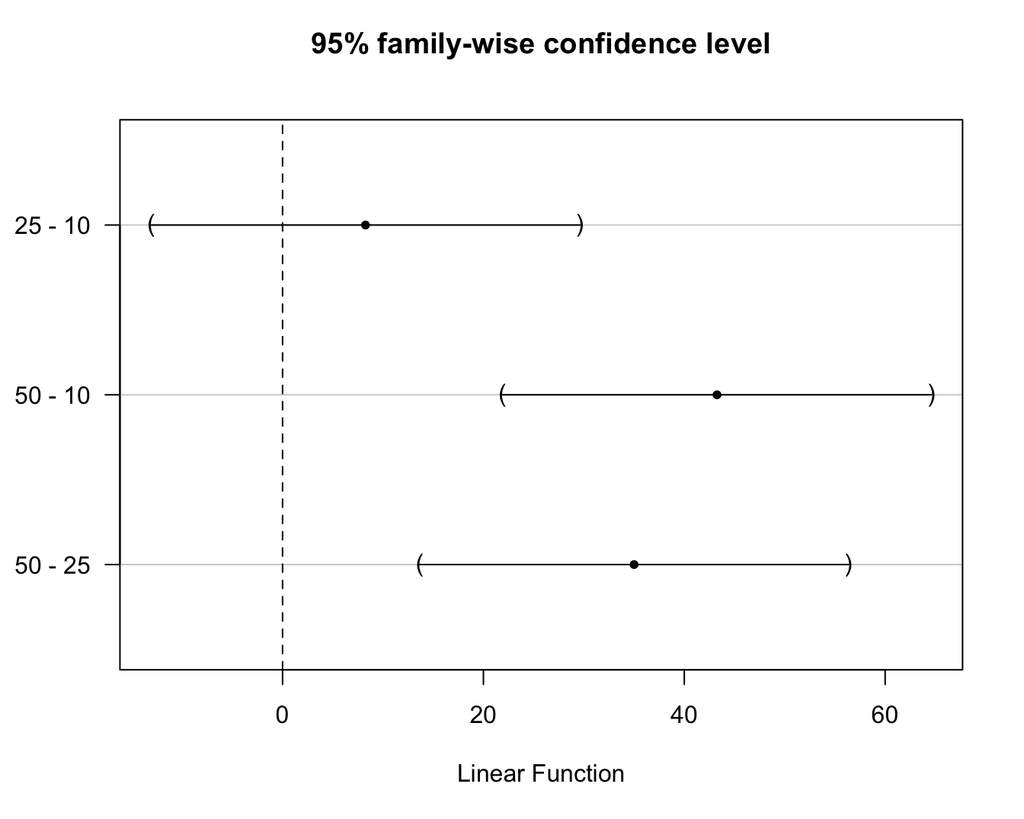

```r
model1.mcp |>
  confint() |>
  plot()
```

### 4.5.2 Evalueer Tukey methode in een simulatiestudie

```r
g <- 3 # aantal behandelingen (g=3)
ni <- 12 # aantal herhalingen in iedere groep
n <- g*ni # totaal aantal observaties
alpha <- 0.05 # significantieniveau van een individuele test
N <- 10000 #aantal simulaties
set.seed(302) #seed zodat resultaten exact geproduceerd kunnen worden
trt <- factor(rep(1:g, ni)) #factor
cnt <- 0 #teller voor aantal foutieve verwerpingen

for(i in 1:N) {
if (i %% 1000 == 0) cat(i, "/", N, "\n")
y <- rnorm(n)
m <- lm(y ~ trt)
m.mcp <- glht(m, linfct = mcp(trt = "Tukey"))
tests <- summary(m.mcp)$test
verwerp <- min(
  as.numeric(tests$pvalues),
  na.rm=T) < alpha
if(verwerp) cnt <- cnt+1
}
```

```
1000 / 10000
2000 / 10000
3000 / 10000
4000 / 10000
5000 / 10000
6000 / 10000
7000 / 10000
8000 / 10000
9000 / 10000
10000 / 10000
```

```r
cnt/N
```

```
[1] 0.0503
```

De methode wordt mooi op het 5% experimentsgewijs significantieniveau gecontroleerd.

# 5 Conclusies: Prostacycline voorbeeld

Volledige analyse voor voorbeeld prostacycline

1. Anova vóór posthoc-tests: F-test heeft een hogere power dan paarsgewijze t-test
   - F-test gebruikt alle gegevens
   - Voor F-test hoeven we niet te corrigeren voor meervoudige testen: er wordt één test uitgevoerd voor de algemene omnibushypothese

```r
model1 <- lm(prostac ~ dose, data = prostacyclin)
anova(model1)
```

```
Analysis of Variance Table

Response: prostac
          Df Sum Sq Mean Sq F value    Pr(>F)
dose       2  12658  6329.0  13.944 4.081e-05 ***
Residuals 33  14979   453.9
---
Signif. codes:  0 '***' 0.001 '**' 0.01 '*' 0.05 '.' 0.1 ' ' 1
```

```r
model1.mcp <- glht(model1, linfct = mcp(dose = "Tukey"))
summary(model1.mcp)
```

```
     Simultaneous Tests for General Linear Hypotheses

Multiple Comparisons of Means: Tukey Contrasts


Fit: lm(formula = prostac ~ dose, data = prostacyclin)

Linear Hypotheses:
             Estimate Std. Error t value Pr(>|t|)
25 - 10 == 0    8.258      8.698   0.949 0.613433
50 - 10 == 0   43.258      8.698   4.974  < 1e-04 ***
50 - 25 == 0   35.000      8.698   4.024 0.000922 ***
---
Signif. codes:  0 '***' 0.001 '**' 0.01 '*' 0.05 '.' 0.1 ' ' 1
(Adjusted p values reported -- single-step method)
```

```r
confint(model1.mcp)
```

```
     Simultaneous Confidence Intervals

Multiple Comparisons of Means: Tukey Contrasts


Fit: lm(formula = prostac ~ dose, data = prostacyclin)

Quantile = 2.4526
95% family-wise confidence level


Linear Hypotheses:
             Estimate lwr      upr
25 - 10 == 0   8.2583 -13.0736  29.5902
50 - 10 == 0  43.2583  21.9264  64.5902
50 - 25 == 0  35.0000  13.6681  56.3319
```

Merk op dat het belangrijk is om ook de niet significante resultaten te vermelden!